# • CV - Ing César Briceño •

César Briceño

2024-04-03

[figure not shown]

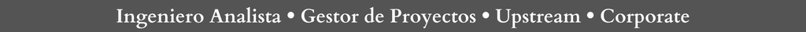

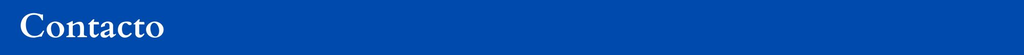

| Celular | Email | Domicilio | RRSS |
| --- | --- | --- | --- |
| 11 27557211 | cesar.joyce.briceno@gmail.com | CABA - Villa Urquiza | @cesar.joyce / LinkedIn |

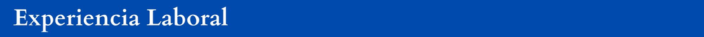

#### Inspector de Calidad - QA/QC | Bureau Veritas

##### Buenos Aires | 2023 - 2024

- Acompaño a cada inspector en su área en la supervisión para la implementación de los procedimientos de calidad que se desprenden del Plan de Inspección y Ensayo del Proyecto de Construcción Planta Compresora de Gas Mercedes.
- Verifico y organizo los registros y documentación de los datos esenciales para la trazabilidad en las áreas de Civil, Piping, Electricidad e Instrumentación.

#### Administrativo de Obra Oil & Gas | Bureau Veritas

##### Buenos Aires | 2022 - 2023

- Gestioné para sus firmas y archivo los documentos de comunicaciones, minutas de reuniones, reportes de inspección.
- Coordiné actividades administrativas para el apoyo logístico del equipo.

#### Ingeniero Analista & Gestor de Proyectos | Viceministerio de Gas - Ministerio de Petróleo

##### Caracas | 2015 - 2022

- Controlé el seguimiento técnico - administrativo de los Planes de Trabajo Anuales de PDVSA y empresas transnacionales adjudicadas con licencias para el desarrollo de lotes de gas natural no asociado.
- Gestioné proyectos internos y actividades del equipo de la Dirección General de Producción de Gas Natural del Ministerio de Petróleo, para la generación de propuestas y presentaciones ejecutivas para el Directorio, reuniones de trabajo con empresas y organizaciones internacionales.

#### Ingeniero de Campo - Perforador Direccional | Halliburton

##### Anzoátegui - Maturin | 2011 - 2014

- Ejecuté planes de perforación como Perforador Direccional de pozos exploratorios y desarrollos en la FPO. Supervisé operaciones de perforación guiando la cuadrilla y controlando los parámetros para garantizar la trayectoria planificada. Elaboré informes sobre los avances de la perforación, gestión de herramientas BHA.
- Tesis y Práctica Universitaria, elaboré en la Gerencia de Perforación de PDVSA PETROPIAR (PDVSA - CHEVRON) un Manual de Perforación de Pozos Horizontales en el Campo Huyaparí de la FPO (2011 - 2012).

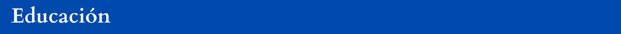

#### Diplomatura en Gestión y Tecnología para el Desarrollo Convencional y No Convencional de Hidrocarburos

- Universidad Nacional Patagonia Austral
- Caleta Olivia | 2023 - Presente

#### Diplomatura Tecnología de Energía Renovable Biogás

- Instituto BIOMA China
- Chengdu | 2017

#### Ingeniería de Petróleo

- Universidad Central de Venezuela
- Caracas | 2012

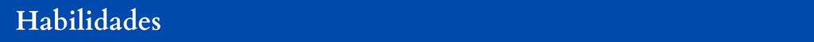

- Idioma Inglés Avanzado
- MS Microsoft
- Lenguaje R (muy básico a partir de estos momentos)
- Emprendimiento: Marca de prendas ORFE | [@Orfeoficial](https://www.instagram.com/orfeoficial/?hl=es) | 2016 - 2021
- Piloto aficionado VANT/Dron Civil - Clase A - Audioviduales
- Co-fundador y Co-productor del canal de Youtube ASIA - Música Electrónica [@ASIA](https://www.youtube.com/@Asiapresents)
- Deportes: baloncesto, voleibol, ultimate frisbee

[figure not shown]